# Notebook

```python
from matplotlib import pyplot as plt
import numpy as np
import pandas as pd
import geopandas as gpd
np.random.seed(42)
```

## Week 10: Clustering Analysis in Python

Nov 7, 2022

## Housekeeping

- Assignment #5 (optional) due one week from today (11/14)
- Assignment #6 (optional) will be assigned this Wednesday 11/9, due on 11/21
- Remember, you have to do one of homeworks #4, #5, or #6

## Recap

- Last week: urban street networks + interactive web maps
- New tools: OSMnx, Pandana, and Folium

## Where we left off last week: choropleth maps in Folium

**Example:** A map of households without internet for US counties

Two ways:

- The easy way: `folium.Choropleth`
- The hard way: `folium.GeoJson`

```python
import folium
```

Load the data, remove counties with no households and add our new column:

```python
# Load CSV data from the data/ folder
census_data = pd.read_csv("./data/internet_avail_census.csv", dtype={"geoid": str})

# Remove counties with no households
valid = census_data['universe'] > 0
census_data = census_data.loc[valid]

# Calculate the percent without internet
census_data['percent_no_internet'] = census_data['no_internet'] / census_data['universe']
```

```python
census_data.head()
```

|  | NAME | universe | no_internet | state | county | geoid | percent_no_internet |
| --- | --- | --- | --- | --- | --- | --- | --- |
| 0 | Washington County, Mississippi | 18299.0 | 6166.0 | 28 | 151 | 28151 | 0.336958 |
| 1 | Perry County, Mississippi | 4563.0 | 1415.0 | 28 | 111 | 28111 | 0.310103 |
| 2 | Choctaw County, Mississippi | 3164.0 | 1167.0 | 28 | 19 | 28019 | 0.368837 |
| 3 | Itawamba County, Mississippi | 8706.0 | 1970.0 | 28 | 57 | 28057 | 0.226281 |
| 4 | Carroll County, Mississippi | 3658.0 | 1218.0 | 28 | 15 | 28015 | 0.332969 |

Load the counties geometry data too:

```python
# Load counties GeoJSOn from the data/ folder
counties = gpd.read_file("./data/us-counties-10m.geojson")
```

```python
counties.head()
```

|  | id | geometry |
| --- | --- | --- |
| 0 | 53073 | MULTIPOLYGON (((-120.85361 49.00011, -120.7674... |
| 1 | 30105 | POLYGON ((-106.11238 48.99904, -106.15187 48.8... |
| 2 | 30029 | POLYGON ((-114.06985 48.99904, -114.05908 48.8... |
| 3 | 16021 | POLYGON ((-116.04755 49.00065, -116.04755 48.5... |
| 4 | 30071 | POLYGON ((-107.17840 49.00011, -107.20712 48.9... |

## The hard way: use folium.GeoJson

- **The good:**
  - More customizable, and can add user interaction
- **The bad:**
  - Requires more work
  - No way to add a legend, see [this open issue on GitHub](https://github.com/python-visualization/folium/issues/528)

## The steps involved

1. Join data and geometry features into a single GeoDataFrame
2. Define a function to style features based on data values
3. Create GeoJSON layer and add it to the map

### Step 1: Join the census data and features

**Note:** this is different than using `folium.Choropleth`, where data and features are stored in two separate data frames.

```python
# Merge the county geometries with census data
# Left column: "id"
# Right column: "geoid"
census_joined = counties.merge(census_data, left_on="id", right_on="geoid")
```

```python
census_joined.head()
```

|  | id | geometry | NAME | universe | no_internet | state | county | geoid | percent_no_internet |
| --- | --- | --- | --- | --- | --- | --- | --- | --- | --- |
| 0 | 53073 | MULTIPOLYGON (((-120.85361 49.00011, -120.7674... | Whatcom County, Washington | 85008.0 | 9189.0 | 53 | 73 | 53073 | 0.108096 |
| 1 | 30105 | POLYGON ((-106.11238 48.99904, -106.15187 48.8... | Valley County, Montana | 3436.0 | 672.0 | 30 | 105 | 30105 | 0.195576 |
| 2 | 30029 | POLYGON ((-114.06985 48.99904, -114.05908 48.8... | Flathead County, Montana | 38252.0 | 5662.0 | 30 | 29 | 30029 | 0.148018 |
| 3 | 16021 | POLYGON ((-116.04755 49.00065, -116.04755 48.5... | Boundary County, Idaho | 4605.0 | 1004.0 | 16 | 21 | 16021 | 0.218024 |
| 4 | 30071 | POLYGON ((-107.17840 49.00011, -107.20712 48.9... | Phillips County, Montana | 1770.0 | 484.0 | 30 | 71 | 30071 | 0.273446 |

### Step 2: Normalize the data column to 0 to 1

- We will use a matplotlib color map that requires data to be between 0 and 1
- Normalize our "percent_no_internet" column to be between 0 and 1

```python
# Minimum
min_val = census_joined['percent_no_internet'].min()

# Maximum
max_val = census_joined['percent_no_internet'].max()

# Calculate a normalized column
normalized = (census_joined['percent_no_internet'] - min_val) / (max_val - min_val)

# Add to the dataframe
census_joined['percent_no_internet_normalized'] = normalized
```

### Step 3: Define our style functions

- Create a matplotlib colormap object using `plt.get_cmap()`
- Color map objects are *functions*: give the function a number between 0 and 1 and it will return a corresponding color from the color map
- Based on the feature data, evaluate the color map and convert to a hex string

```python
import matplotlib.colors as mcolors
```

```python
# Use a red-purple colorbrewer color scheme
cmap = plt.get_cmap('RdPu')
```

```python
# The minimum value of the color map as an RGB tuple
cmap(0)
```

```
(1.0, 0.9686274509803922, 0.9529411764705882, 1.0)
```

```python
# The minimum value of the color map as a hex string
mcolors.rgb2hex(cmap(0.0))
```

```
'#fff7f3'
```

```python
# The maximum value of the color map as a hex string
mcolors.rgb2hex(cmap(1.0))
```

```
'#49006a'
```

```python
def get_style(feature):
    """
    Given an input GeoJSON feature, return a style dict.

    Notes
    -----
    The color in the style dict is determined by the
    "percent_no_internet_normalized" column in the
    input "feature".
    """
    # Get the data value from the feature
    value = feature['properties']['percent_no_internet_normalized']

    # Evaluate the color map
    # NOTE: value must between 0 and 1
    rgb_color = cmap(value) # this is an RGB tuple

    # Convert to hex string
    color = mcolors.rgb2hex(rgb_color)

    # Return the style dictionary
    return {'weight': 0.5, 'color': color, 'fillColor': color, "fillOpacity": 0.75}
```

```python
def get_highlighted_style(feature):
    """
    Return a style dict to use when the user highlights a
    feature with the mouse.
    """

    return {"weight": 3, "color": "black"}
```

### Step 4: Convert our data to GeoJSON

- **Tip**: To limit the amount of data Folium has to process, it's best to trim our GeoDataFrame to only the columns we'll need before converting to GeoJSON
- You can use the `.to_json()` function to convert to a GeoJSON string

```python
needed_cols = ['NAME', 'percent_no_internet', 'percent_no_internet_normalized', 'geometry']
census_json = census_joined[needed_cols].to_json()
```

```python
# STEP 1: Initialize the map
m = folium.Map(location=[40, -98], zoom_start=4)

# STEP 2: Add the GeoJson to the map
folium.GeoJson(
    census_json, # The geometry + data columns in GeoJSON format
    style_function=get_style, # The style function to color counties differently
    highlight_function=get_highlighted_style,
    tooltip=folium.GeoJsonTooltip(['NAME', 'percent_no_internet'])
).add_to(m)



# avoid a rendering bug by saving as HTML and re-loading
m.save('percent_no_internet.html')
```

## And viola!

The hard way is **harder**, but we have a tooltip and highlight interactivity!

```python
from IPython.display import IFrame
```

```python
IFrame('percent_no_internet.html', width=800, height=500)
```

[interactive chart not shown]

## At-home exercise: Can we repeat this with altair?

Try to replicate the above interactive map exactly (minus the background tiles). This includes:

- Using the red-purple colorbrewer scheme
- Having a tooltip with the percentage and county name

**Hints**

- The altair example gallery includes a good choropleth example: https://altair-viz.github.io/gallery/choropleth.html
- See [altair documentation](https://altair-viz.github.io/user_guide/customization.html#color-schemes) on changing the color scheme and the [Vega documentation](https://vega.github.io/vega/docs/schemes/#reference) for the names of the allowed color schemes in altair
- You'll want to specify the projection type as "albersUsa"

```python
import altair as alt
```

```python
# Initialize the chart with the counties data
alt.Chart(counties).mark_geoshape(stroke="white", strokeWidth=0.25).encode(
    # Encode the color
    color=alt.Color(
        "percent_no_internet:Q",
        title="Percent Without Internet",
        scale=alt.Scale(scheme="redpurple"),
        legend=alt.Legend(format=".0%")
    ),
    # Tooltip
    tooltip=[
        alt.Tooltip("NAME:N", title="Name"),
        alt.Tooltip("percent_no_internet:Q", title="Percent Without Internet", format=".1%"),
    ],
).transform_lookup(
    lookup="id", # The column name in the counties data to match on
    from_=alt.LookupData(census_data, "geoid", ["percent_no_internet", "NAME"]), # Match census data on "geoid"
).project(
    type="albersUsa"
).properties(
    width=700, height=500
)
```

[interactive chart not shown]

## Leaflet/Folium plugins

One of leaflet's strengths: a rich set of open-source plugins

https://leafletjs.com/plugins.html

Many of these are available in Folium!

## Example: Heatmap

```python
from folium.plugins import HeatMap
```

```python
HeatMap?
```

```
Init signature:
HeatMap(
    data,
    name=None,
    min_opacity=0.5,
    max_zoom=18,
    radius=25,
    blur=15,
    gradient=None,
    overlay=True,
    control=True,
    show=True,
    **kwargs,
)
Docstring:
Create a Heatmap layer

Parameters
----------
data : list of points of the form [lat, lng] or [lat, lng, weight]
    The points you want to plot.
    You can also provide a numpy.array of shape (n,2) or (n,3).
name : string, default None
    The name of the Layer, as it will appear in LayerControls.
min_opacity  : default 1.
    The minimum opacity the heat will start at.
max_zoom : default 18
    Zoom level where the points reach maximum intensity (as intensity
    scales with zoom), equals maxZoom of the map by default
radius : int, default 25
    Radius of each "point" of the heatmap
blur : int, default 15
    Amount of blur
gradient : dict, default None
    Color gradient config. e.g. {0.4: 'blue', 0.65: 'lime', 1: 'red'}
overlay : bool, default True
    Adds the layer as an optional overlay (True) or the base layer (False).
control : bool, default True
    Whether the Layer will be included in LayerControls.
show: bool, default True
    Whether the layer will be shown on opening (only for overlays).
File:           ~/mambaforge/envs/musa-550-fall-2022/lib/python3.9/site-packages/folium/plugins/heat_map.py
Type:           type
Subclasses:
```

## Example: A heatmap of new construction permits in Philadelphia in the last 30 days

New construction in Philadelphia requires a building permit, which we can pull from Open Data Philly.

- Data available from OpenDataPhilly: https://www.opendataphilly.org/dataset/licenses-and-inspections-building-permits
- Query the database API directly to get the GeoJSON
- We can use the `carto2gpd` package to get the data
- API documentation: https://cityofphiladelphia.github.io/carto-api-explorer/#permits

### Step 1: Download the data from CARTO

**The "current_date" variable in SQL databases**

You can use the pre-defined "current_date" variable to get the current date. For example, to get the permits from the past 30 days, we could do:

`SELECT * FROM permits WHERE permitissuedate >= current_date - 30`

**Selecting only new construction permits**

To select new construction permits, you can use the "permitdescription" field. There are two relevant categories:

- "RESIDENTIAL BUILDING PERMIT"
- "COMMERCIAL BUILDING PERMIT"

We can use the SQL `IN` command ([documentation](https://www.w3schools.com/sql/sql_in.asp)) to easily select rows that have these categories.

```python
import carto2gpd
```

```python
# API URL
url = "https://phl.carto.com/api/v2/sql"

# Table name on CARTO
table_name = "permits"

# The where clause, with two parts
DAYS = 30
where = f"permitissuedate >= current_date - {DAYS}"
where += " and permitdescription IN ('RESIDENTIAL BUILDING PERMIT', 'COMMERCIAL BUILDING PERMIT')"

where
```

```
"permitissuedate >= current_date - 30 and permitdescription IN ('RESIDENTIAL BUILDING PERMIT', 'COMMERCIAL BUILDING PERMIT')"
```

```python
# Run the query
permits = carto2gpd.get(url, table_name, where=where)
```

```python
len(permits)
```

```
493
```

```python
permits.head()
```

|  | geometry | cartodb_id | objectid | permitnumber | addressobjectid | parcel_id_num | permittype | permitdescription | commercialorresidential | typeofwork | ... | unit_type | unit_num | zip | censustract | council_district | opa_owner | systemofrecord | geocode_x | geocode_y | posse_jobid |
| --- | --- | --- | --- | --- | --- | --- | --- | --- | --- | --- | --- | --- | --- | --- | --- | --- | --- | --- | --- | --- | --- |
| 0 | POINT (-75.16551 40.04532) | 4461 | 4898 | CP-2022-002038 | 15732535 | 210522 | BUILDING | COMMERCIAL BUILDING PERMIT | COMMERCIAL | ADDITION AND/OR ALTERATION | ... | None | None | 19144-1206 | 248 | 8 | GAROFALO HELEN V | ECLIPSE | 2.691986e+06 | 269953.280616 | 465300244 |
| 1 | POINT (-75.00539 40.03600) | 4768 | 4904 | CP-2022-003337 | 156760706 | 440714 | BUILDING | COMMERCIAL BUILDING PERMIT | COMMERCIAL | NEW CONSTRUCTION | ... | None | None | 19136-1604 | 9891 | 6 | PHILA MUNICIPAL AUTH | ECLIPSE | 2.736901e+06 | 267914.438827 | 486707349 |
| 2 | POINT (-75.09335 40.05158) | 4789 | 4909 | CP-2022-004987 | 184460163 | 352755 | BUILDING | COMMERCIAL BUILDING PERMIT | COMMERCIAL | ADDITION AND/OR ALTERATION | ... | None | None | 19111-5246 | 306 | 9 | GRACE YANG INC | ECLIPSE | 2.712111e+06 | 272832.652136 | 514998496 |
| 3 | POINT (-75.16733 40.06235) | 5514 | 5680 | RP-2022-005876 | 265435068 | 331238 | RESIDENTIAL BUILDING | RESIDENTIAL BUILDING PERMIT | RESIDENTIAL | ADDITION AND/OR ALTERATION | ... | None | None | 19150-3300 | 264 | 9 | CMPJ LLC | ECLIPSE | 2.691293e+06 | 276139.761238 | 480078356 |
| 4 | POINT (-75.22938 39.93547) | 5537 | 5683 | RP-2022-007783 | 132249898 | 366914 | RESIDENTIAL BUILDING | RESIDENTIAL BUILDING PERMIT | RESIDENTIAL | ADDITION AND/OR ALTERATION | ... | None | None | 19143-5516 | 65 | 2 | DH1 FUND LP | ECLIPSE | 2.675252e+06 | 229438.672154 | 497420889 |

5 rows × 33 columns

### Step 2: Remove missing geometries

Some permits don't have locations — use the `.geometry.notnull()` function to trim the data frame to those incidents with valid geometries.

```python
permits = permits.loc[permits.geometry.notnull()].copy()
```

### Step 3: Extract out the lat/lng coordinates

**Note:** We need an array of (latitude, longitude) pairs. Be careful about the order!

```python
# Extract the lat and longitude from the geometery column
permits['lat'] = permits.geometry.y
permits['lng'] = permits.geometry.x
```

```python
permits.head()
```

|  | geometry | cartodb_id | objectid | permitnumber | addressobjectid | parcel_id_num | permittype | permitdescription | commercialorresidential | typeofwork | ... | zip | censustract | council_district | opa_owner | systemofrecord | geocode_x | geocode_y | posse_jobid | lat | lng |
| --- | --- | --- | --- | --- | --- | --- | --- | --- | --- | --- | --- | --- | --- | --- | --- | --- | --- | --- | --- | --- | --- |
| 0 | POINT (-75.16551 40.04532) | 4461 | 4898 | CP-2022-002038 | 15732535 | 210522 | BUILDING | COMMERCIAL BUILDING PERMIT | COMMERCIAL | ADDITION AND/OR ALTERATION | ... | 19144-1206 | 248 | 8 | GAROFALO HELEN V | ECLIPSE | 2.691986e+06 | 269953.280616 | 465300244 | 40.045317 | -75.165507 |
| 1 | POINT (-75.00539 40.03600) | 4768 | 4904 | CP-2022-003337 | 156760706 | 440714 | BUILDING | COMMERCIAL BUILDING PERMIT | COMMERCIAL | NEW CONSTRUCTION | ... | 19136-1604 | 9891 | 6 | PHILA MUNICIPAL AUTH | ECLIPSE | 2.736901e+06 | 267914.438827 | 486707349 | 40.036004 | -75.005385 |
| 2 | POINT (-75.09335 40.05158) | 4789 | 4909 | CP-2022-004987 | 184460163 | 352755 | BUILDING | COMMERCIAL BUILDING PERMIT | COMMERCIAL | ADDITION AND/OR ALTERATION | ... | 19111-5246 | 306 | 9 | GRACE YANG INC | ECLIPSE | 2.712111e+06 | 272832.652136 | 514998496 | 40.051579 | -75.093348 |
| 3 | POINT (-75.16733 40.06235) | 5514 | 5680 | RP-2022-005876 | 265435068 | 331238 | RESIDENTIAL BUILDING | RESIDENTIAL BUILDING PERMIT | RESIDENTIAL | ADDITION AND/OR ALTERATION | ... | 19150-3300 | 264 | 9 | CMPJ LLC | ECLIPSE | 2.691293e+06 | 276139.761238 | 480078356 | 40.062348 | -75.167333 |
| 4 | POINT (-75.22938 39.93547) | 5537 | 5683 | RP-2022-007783 | 132249898 | 366914 | RESIDENTIAL BUILDING | RESIDENTIAL BUILDING PERMIT | RESIDENTIAL | ADDITION AND/OR ALTERATION | ... | 19143-5516 | 65 | 2 | DH1 FUND LP | ECLIPSE | 2.675252e+06 | 229438.672154 | 497420889 | 39.935474 | -75.229383 |

5 rows × 35 columns

```python
# Split out the residential and commercial
residential = permits.query("permitdescription == 'RESIDENTIAL BUILDING PERMIT'")
commercial = permits.query("permitdescription == 'COMMERCIAL BUILDING PERMIT'")
```

```python
# Make a NumPy array (use the "values" attribute)
residential_coords = residential[['lat', 'lng']].values
commercial_coords = commercial[['lat', 'lng']].values
```

```python
commercial_coords[:5]
```

```
array([[ 40.045317, -75.165507],
       [ 40.036004, -75.005385],
       [ 40.051579, -75.093348],
       [ 39.951968, -75.156049],
       [ 39.969465, -75.2167  ]])
```

### Step 4: Make a Folium map and add a HeatMap

The HeatMap takes the list of coordinates: **the first column is latitude and the second column longitude**

### Commercial building permits

```python
# Initialize map
m = folium.Map(
    location=[39.99, -75.13],
    tiles='Cartodb Positron',
    zoom_start=12
)


# Add heat map coordinates
HeatMap(commercial_coords).add_to(m)

m
```

Make this Notebook Trusted to load map: File -> Trust Notebook

[interactive chart not shown]

### Residential building permits

```python
# Initialize map
m = folium.Map(
    location=[39.99, -75.13],
    tiles='Cartodb Positron',
    zoom_start=12
)


# Add heat map
HeatMap(residential_coords, radius=15).add_to(m)

m
```

Make this Notebook Trusted to load map: File -> Trust Notebook

[interactive chart not shown]

### Takeaways

Commercial construction concentrated in the greater Center City area while residential construction is primarily outside of Center City...

## That's it for interactive maps w/ Folium...

Now on to clustering...

## Clustering in Python

- Both spatial and non-spatial datasets
- Two new techniques:
  - Non-spatial: **K-means**
  - Spatial: **DBSCAN**
- Two labs/exercises this week:
  1. Grouping Philadelphia neighborhoods by AirBnb listings
  2. Identifying clusters in taxi rides in NYC

## "Machine learning"

[figure not shown]

- The computer **learns** patterns and properties of an input data set without the user specifying them beforehand
- Can be both **supervised** and **unsupervised**

### Supervised

- Example: classification
- Given a training set of **labeled** data, learn to assign labels to new data

### Unsupervised

- Example: clustering
- Identify structure / clusters in data without any prior knowledge

## Machine learning in Python: scikit-learn

- State-of-the-art machine learning in Python
- Easy to use, lots of functionality

## Clustering is just one (of many) features

[figure not shown]

https://scikit-learn.org/stable/

**Note:** We will focus on clustering algorithms today and discuss a few other machine learning techniques in the next two weeks. If there is a specific scikit-learn use case we won't cover, I'm open to ideas for incorporating it as part of the final project.

## Part 1: Non-spatial clustering

**The goal**

Partition a dataset into groups that have a similar set of attributes, **or features**, within the group and a dissimilar set of features between groups.

Minimize the *intra-cluster* variance and maximize the *inter-cluster* variance of features.

## Some intuition

[figure not shown]

## K-Means clustering

- Simple but robust clustering algorithm
- Widely used
- **Important:** user must specify the number of clusters
- **Cannot** be used to find density-based clusters

## This is just one of several clustering methods

https://scikit-learn.org/stable/modules/clustering.html#overview-of-clustering-methods

## A good introduction

[Andrew Ng's Coursera lecture](https://www.youtube.com/watch?v=hDmNF9JG3lo&feature=youtu.be)

## How does it work?

**Minimizes the intra-cluster variance**: minimizes the sum of the squared distances between all points in a cluster and the cluster centroid

## K-means in action

[figure not shown]

## Example: Clustering countries by health and income

- Health expectancy in years vs. GDP per capita and population for 187 countries (as of 2015)
- Data from [Gapminder](https://www.gapminder.org/data/)

```python
import altair as alt
from vega_datasets import data as vega_data
```

Read the data from a URL:

```python
gapminder = pd.read_csv(vega_data.gapminder_health_income.url)
gapminder.head()
```

|  | country | income | health | population |
| --- | --- | --- | --- | --- |
| 0 | Afghanistan | 1925 | 57.63 | 32526562 |
| 1 | Albania | 10620 | 76.00 | 2896679 |
| 2 | Algeria | 13434 | 76.50 | 39666519 |
| 3 | Andorra | 46577 | 84.10 | 70473 |
| 4 | Angola | 7615 | 61.00 | 25021974 |

## Plot it with altair

```python
(
    alt.Chart(gapminder)
    .mark_circle()
    .encode(
        alt.X("income:Q", scale=alt.Scale(type="log")),
        alt.Y("health:Q", scale=alt.Scale(zero=False)),
        size="population:Q",
        tooltip=list(gapminder.columns),
    )
    .properties(width=800, height=600)
    .interactive()
)
```

[interactive chart not shown]

## K-Means with scikit-learn

```python
from sklearn.cluster import KMeans
```

Let's start with 5 clusters

```python
KMeans?
```

```
Init signature:
KMeans(
    n_clusters=8,
    *,
    init='k-means++',
    n_init=10,
    max_iter=300,
    tol=0.0001,
    verbose=0,
    random_state=None,
    copy_x=True,
    algorithm='lloyd',
)
Docstring:
K-Means clustering.

Read more in the :ref:`User Guide <k_means>`.

Parameters
----------

n_clusters : int, default=8
    The number of clusters to form as well as the number of
    centroids to generate.

init : {'k-means++', 'random'}, callable or array-like of shape             (n_clusters, n_features), default='k-means++'
    Method for initialization:

    'k-means++' : selects initial cluster centroids using sampling based on
    an empirical probability distribution of the points' contribution to the
    overall inertia. This technique speeds up convergence, and is
    theoretically proven to be :math:`\mathcal{O}(\log k)`-optimal.
    See the description of `n_init` for more details.

    'random': choose `n_clusters` observations (rows) at random from data
    for the initial centroids.

    If an array is passed, it should be of shape (n_clusters, n_features)
    and gives the initial centers.

```

[output cut: 112 more lines]

```
>>> from sklearn.cluster import KMeans
>>> import numpy as np
>>> X = np.array([[1, 2], [1, 4], [1, 0],
...               [10, 2], [10, 4], [10, 0]])
>>> kmeans = KMeans(n_clusters=2, random_state=0).fit(X)
>>> kmeans.labels_
array([1, 1, 1, 0, 0, 0], dtype=int32)
>>> kmeans.predict([[0, 0], [12, 3]])
array([1, 0], dtype=int32)
>>> kmeans.cluster_centers_
array([[10.,  2.],
       [ 1.,  2.]])
File:           ~/mambaforge/envs/musa-550-fall-2022/lib/python3.9/site-packages/sklearn/cluster/_kmeans.py
Type:           ABCMeta
Subclasses:
```

```python
kmeans = KMeans(n_clusters=5)
```

Lot's of optional parameters, but `n_clusters` is the most important:

## Let's fit just income first

Use the `fit()` function

```python
kmeans.fit(gapminder[['income']]);
```

## Extract the cluster labels

Use the `labels_` attribute

```python
gapminder['label'] = kmeans.labels_
```

## How big are our clusters?

```python
gapminder.groupby('label').size()
```

```
label
0    106
1     24
2      6
3     50
4      1
dtype: int64
```

## Plot it again, coloring by our labels

```python
(
    alt.Chart(gapminder)
    .mark_circle()
    .encode(
        alt.X("income:Q", scale=alt.Scale(type="log")),
        alt.Y("health:Q", scale=alt.Scale(zero=False)),
        size="population:Q",
        color=alt.Color("label:N", scale=alt.Scale(scheme="dark2")),
        tooltip=list(gapminder.columns),
    )
    .properties(width=800, height=600)
    .interactive()
)
```

[interactive chart not shown]

### Calculate average income by group

```python
gapminder.groupby("label")['income'].mean().sort_values()
```

```
label
0      5279.830189
3     21040.820000
1     42835.500000
2     74966.166667
4    132877.000000
Name: income, dtype: float64
```

Data is nicely partitioned into income levels

## How about health, income, and population?

```python
# Fit all three columns
kmeans.fit(gapminder[['income', 'health', 'population']])

# Extract the labels
gapminder['label'] = kmeans.labels_
```

```python
gapminder
```

|  | country | income | health | population | label |
| --- | --- | --- | --- | --- | --- |
| 0 | Afghanistan | 1925 | 57.63 | 32526562 | 4 |
| 1 | Albania | 10620 | 76.00 | 2896679 | 4 |
| 2 | Algeria | 13434 | 76.50 | 39666519 | 0 |
| 3 | Andorra | 46577 | 84.10 | 70473 | 4 |
| 4 | Angola | 7615 | 61.00 | 25021974 | 4 |
| ... | ... | ... | ... | ... | ... |
| 182 | Vietnam | 5623 | 76.50 | 93447601 | 0 |
| 183 | West Bank and Gaza | 4319 | 75.20 | 4668466 | 4 |
| 184 | Yemen | 3887 | 67.60 | 26832215 | 4 |
| 185 | Zambia | 4034 | 58.96 | 16211767 | 4 |
| 186 | Zimbabwe | 1801 | 60.01 | 15602751 | 4 |

187 rows × 5 columns

```python
(
    alt.Chart(gapminder)
    .mark_circle()
    .encode(
        alt.X("income:Q", scale=alt.Scale(type="log")),
        alt.Y("health:Q", scale=alt.Scale(zero=False)),
        size="population:Q",
        color=alt.Color("label:N", scale=alt.Scale(scheme="dark2")),
        tooltip=list(gapminder.columns),
    )
    .properties(width=800, height=600)
    .interactive()
)
```

[interactive chart not shown]

### It....didn't work that well

What's wrong?

**K-means is distance-based, but our features have wildly different distance scales**

## scikit-learn to the rescue: pre-processing

- Scikit-learn has a utility to normalize features with an average of zero and a variance of 1
- Use the [`StandardScaler`](https://scikit-learn.org/stable/modules/generated/sklearn.preprocessing.StandardScaler.html) class

```python
from sklearn.preprocessing import MinMaxScaler, RobustScaler
```

```python
from sklearn.preprocessing import StandardScaler
```

```python
scaler = StandardScaler()
```

## Use the `fit_transform()` function to scale your features

```python
gapminder_scaled = scaler.fit_transform(gapminder[['income', 'health', 'population']])
```

**Important**: The `fit_transform()` function converts the DataFrame to a numpy array:

```python
# fit_transform() converts the data into a numpy array
gapminder_scaled[:5]
```

```
array([[-0.79481258, -1.8171424 , -0.04592039],
       [-0.34333373,  0.55986273, -0.25325837],
       [-0.1972197 ,  0.62456075,  0.00404216],
       [ 1.52369617,  1.6079706 , -0.27303503],
       [-0.49936524, -1.38107777, -0.09843447]])
```

```python
# mean of zero
gapminder_scaled.mean(axis=0)
```

```
array([ 8.07434927e-17, -1.70511258e-15, -1.89984689e-17])
```

```python
# variance of one
gapminder_scaled.std(axis=0)
```

```
array([1., 1., 1.])
```

## Now fit the scaled features

```python
# Perform the fit
kmeans.fit(gapminder_scaled)

# Extract the labels
gapminder['label'] = kmeans.labels_
```

```python
(
    alt.Chart(gapminder)
    .mark_circle()
    .encode(
        alt.X("income:Q", scale=alt.Scale(type="log")),
        alt.Y("health:Q", scale=alt.Scale(zero=False)),
        size="population:Q",
        color=alt.Color("label:N", scale=alt.Scale(scheme="dark2")),
        tooltip=list(gapminder.columns),
    )
    .properties(width=800, height=600)
    .interactive()
)
```

[interactive chart not shown]

```python
# Number of countries per cluster
gapminder.groupby("label").size()
```

```
label
0    86
1     2
2    32
3    61
4     6
dtype: int64
```

```python
# Average population per cluster
gapminder.groupby("label")['population'].mean().sort_values() / 1e6
```

```
label
4       2.988746
3      21.441296
0      26.239937
2      32.501032
1    1343.549735
Name: population, dtype: float64
```

```python
# Average life expectancy per cluster
gapminder.groupby("label")['health'].mean().sort_values()
```

```
label
3    62.232951
1    71.850000
0    74.313837
2    80.806250
4    81.033333
Name: health, dtype: float64
```

```python
# Average income per cluster
gapminder.groupby("label")['income'].mean().sort_values() / 1e3
```

```
label
3     4.150623
1     9.618500
0    13.229907
2    40.322094
4    86.987500
Name: income, dtype: float64
```

```python
gapminder.loc[gapminder['label']==4]
```

|  | country | income | health | population | label |
| --- | --- | --- | --- | --- | --- |
| 24 | Brunei | 73003 | 78.7 | 423188 | 4 |
| 88 | Kuwait | 82633 | 80.7 | 3892115 | 4 |
| 97 | Luxembourg | 88314 | 81.1 | 567110 | 4 |
| 124 | Norway | 64304 | 81.6 | 5210967 | 4 |
| 134 | Qatar | 132877 | 82.0 | 2235355 | 4 |
| 145 | Singapore | 80794 | 82.1 | 5603740 | 4 |

```python
kmeans.inertia_
```

```
80.84493050696736
```

```python
gapminder.loc[gapminder['label']==4]
```

|  | country | income | health | population | label |
| --- | --- | --- | --- | --- | --- |
| 24 | Brunei | 73003 | 78.7 | 423188 | 4 |
| 88 | Kuwait | 82633 | 80.7 | 3892115 | 4 |
| 97 | Luxembourg | 88314 | 81.1 | 567110 | 4 |
| 124 | Norway | 64304 | 81.6 | 5210967 | 4 |
| 134 | Qatar | 132877 | 82.0 | 2235355 | 4 |
| 145 | Singapore | 80794 | 82.1 | 5603740 | 4 |

## Exercise: Clustering neighborhoods by Airbnb stats

I've extracted neighborhood Airbnb statistics for Philadelphia neighborhoods from [Tom Slee's website](http://tomslee.net/airbnb-data).

The data includes average price per person, overall satisfaction, and number of listings.

## Two good references for Airbnb data

- [Tom Slee's website](http://tomslee.net/airbnb-data)
- [Inside Airbnb](http://insideairbnb.com/get-the-data.html)

Original research study: [How Airbnb's Data Hid the Facts in New York City](http://insideairbnb.com/reports/how-airbnbs-data-hid-the-facts-in-new-york-city.pdf)

### Step 1: Load the data with pandas

The data is available in CSV format ("philly_airbnb_by_neighborhoods.csv") in the "data/" folder of the repository.

```python
airbnb = pd.read_csv("data/philly_airbnb_by_neighborhoods.csv")
airbnb.head()
```

|  | neighborhood | price_per_person | overall_satisfaction | N |
| --- | --- | --- | --- | --- |
| 0 | ALLEGHENY_WEST | 120.791667 | 4.666667 | 23 |
| 1 | BELLA_VISTA | 87.407920 | 3.158333 | 204 |
| 2 | BELMONT | 69.425000 | 3.250000 | 11 |
| 3 | BREWERYTOWN | 71.788188 | 1.943182 | 142 |
| 4 | BUSTLETON | 55.833333 | 1.250000 | 19 |

### Step 2: Perform the K-Means fit

```python
# Initialize the Kmeans object
kmeans = KMeans(n_clusters=5, random_state=42)
```

```python
# Scale the data features we want
scaler = StandardScaler()
scaled_airbnb_data = scaler.fit_transform(airbnb[['price_per_person', 'overall_satisfaction', 'N']])
```

```python
# Run the fit!
kmeans.fit(scaled_airbnb_data)
```

```
KMeans(n_clusters=5, random_state=42)
```

```python
# Save the cluster labels
airbnb["label"] = kmeans.labels_
```

```python
# New column "label"!
airbnb.head()
```

|  | neighborhood | price_per_person | overall_satisfaction | N | label |
| --- | --- | --- | --- | --- | --- |
| 0 | ALLEGHENY_WEST | 120.791667 | 4.666667 | 23 | 2 |
| 1 | BELLA_VISTA | 87.407920 | 3.158333 | 204 | 2 |
| 2 | BELMONT | 69.425000 | 3.250000 | 11 | 2 |
| 3 | BREWERYTOWN | 71.788188 | 1.943182 | 142 | 1 |
| 4 | BUSTLETON | 55.833333 | 1.250000 | 19 | 1 |

### Step 3: Calculate average features per cluster

To gain some insight into our clusters, after calculating the K-Means labels:

- group by the `label` column
- calculate the `mean()` of each of our features
- calculate the number of neighborhoods per cluster

```python
airbnb.groupby('label', as_index=False).size()
```

|  | label | size |
| --- | --- | --- |
| 0 | 0 | 21 |
| 1 | 1 | 23 |
| 2 | 2 | 59 |
| 3 | 3 | 1 |
| 4 | 4 | 1 |

```python
airbnb.groupby('label', as_index=False).mean().sort_values(by='price_per_person')
```

|  | label | price_per_person | overall_satisfaction | N |
| --- | --- | --- | --- | --- |
| 2 | 2 | 67.526755 | 3.232236 | 69.864407 |
| 1 | 1 | 78.935232 | 0.920238 | 38.347826 |
| 0 | 0 | 119.329173 | 2.947605 | 313.000000 |
| 4 | 4 | 136.263996 | 3.000924 | 1499.000000 |
| 3 | 3 | 387.626984 | 5.000000 | 31.000000 |

```python
airbnb.loc[airbnb['label'] == 2]
```

|  | neighborhood | price_per_person | overall_satisfaction | N | label |
| --- | --- | --- | --- | --- | --- |
| 0 | ALLEGHENY_WEST | 120.791667 | 4.666667 | 23 | 2 |
| 1 | BELLA_VISTA | 87.407920 | 3.158333 | 204 | 2 |
| 2 | BELMONT | 69.425000 | 3.250000 | 11 | 2 |
| 5 | CALLOWHILL | 94.733269 | 3.017241 | 143 | 2 |
| 6 | CEDAR_PARK | 39.053171 | 3.220000 | 261 | 2 |
| 8 | CHESTNUT_HILL | 69.123478 | 3.444444 | 74 | 2 |
| 9 | CHINATOWN | 48.476667 | 2.984848 | 101 | 2 |
| 11 | DICKINSON_NARROWS | 62.626393 | 3.227273 | 125 | 2 |
| 12 | EASTWICK | 63.566667 | 2.142857 | 18 | 2 |
| 13 | EAST_FALLS | 64.491228 | 2.522222 | 156 | 2 |
| 14 | EAST_KENSINGTON | 58.984428 | 2.602564 | 108 | 2 |
| 15 | EAST_OAK_LANE | 113.243590 | 4.800000 | 20 | 2 |
| 17 | EAST_PASSYUNK | 81.253676 | 3.716981 | 190 | 2 |
| 18 | EAST_POPLAR | 69.164368 | 3.350000 | 36 | 2 |
| 24 | FRANKFORD | 28.500000 | 3.583333 | 19 | 2 |
| 25 | FRANKLINVILLE | 74.968750 | 2.409091 | 12 | 2 |
| 26 | GARDEN_COURT | 45.954375 | 3.467391 | 93 | 2 |
| 27 | GERMANTOWN_EAST | 86.875000 | 3.750000 | 12 | 2 |
| 28 | GERMANTOWN_MORTON | 37.357143 | 3.750000 | 12 | 2 |
| 29 | GERMANTOWN_PENN_KNOX | 36.030702 | 4.666667 | 21 | 2 |
| 30 | GERMANTOWN_SOUTHWEST | 39.105263 | 3.083333 | 25 | 2 |
| 31 | GERMANTOWN_WESTSIDE | 49.830128 | 2.375000 | 27 | 2 |
| 32 | GERMANTOWN_WEST_CENT | 57.004884 | 2.891892 | 90 | 2 |
| 33 | GERMANY_HILL | 135.208333 | 5.000000 | 20 | 2 |
| 34 | GIRARD_ESTATES | 90.461111 | 2.875000 | 78 | 2 |
| 36 | GRAYS_FERRY | 66.833535 | 3.035714 | 65 | 2 |
| 37 | GREENWICH | 57.557576 | 2.500000 | 14 | 2 |
| 39 | HARROWGATE | 24.796429 | 3.458333 | 16 | 2 |
| 40 | HARTRANFT | 77.105300 | 2.800000 | 73 | 2 |
| 41 | HAVERFORD_NORTH | 102.025000 | 4.000000 | 11 | 2 |
| 44 | KINGSESSING | 41.005000 | 2.781250 | 44 | 2 |
| 46 | LOGAN | 63.582598 | 2.800000 | 18 | 2 |
| 48 | LOWER_MOYAMENSING | 72.605479 | 2.838710 | 100 | 2 |
| 49 | LUDLOW | 63.333333 | 4.400000 | 11 | 2 |
| 51 | MANTUA | 96.527778 | 2.968750 | 162 | 2 |
| 53 | MILL_CREEK | 53.020833 | 4.357143 | 37 | 2 |
| 54 | MOUNT_AIRY_EAST | 47.598086 | 3.435484 | 93 | 2 |
| 55 | MOUNT_AIRY_WEST | 52.799916 | 3.468750 | 115 | 2 |
| 56 | NEWBOLD | 82.836628 | 2.976190 | 121 | 2 |
| 59 | OGONTZ | 35.389194 | 2.250000 | 13 | 2 |
| 61 | OLD_KENSINGTON | 75.641209 | 2.945946 | 118 | 2 |
| 62 | OLNEY | 66.591479 | 2.416667 | 22 | 2 |
| 66 | PASCHALL | 21.722222 | 4.071429 | 12 | 2 |
| 67 | PASSYUNK_SQUARE | 86.239845 | 3.742647 | 232 | 2 |
| 68 | PENNSPORT | 88.773897 | 3.100000 | 100 | 2 |
| 71 | POWELTON | 77.697032 | 2.673077 | 79 | 2 |
| 74 | RICHMOND | 79.432611 | 2.613636 | 71 | 2 |
| 77 | ROXBOROUGH | 88.504646 | 3.270833 | 124 | 2 |
| 81 | SOUTHWEST_SCHUYLKILL | 83.098639 | 2.375000 | 26 | 2 |
| 84 | STADIUM_DISTRICT | 118.981061 | 2.875000 | 31 | 2 |
| 87 | TIOGA | 44.636364 | 3.833333 | 14 | 2 |
| 89 | UPPER_ROXBOROUGH | 96.724194 | 3.230769 | 43 | 2 |
| 90 | WALNUT_HILL | 55.033582 | 3.104167 | 82 | 2 |
| 92 | WEST_KENSINGTON | 39.422287 | 3.119048 | 54 | 2 |
| 94 | WEST_PASSYUNK | 48.846491 | 3.500000 | 48 | 2 |
| 96 | WEST_POWELTON | 59.056780 | 2.733333 | 139 | 2 |
| 97 | WHITMAN | 63.386458 | 3.409091 | 50 | 2 |
| 98 | WISSAHICKON | 62.733060 | 2.600000 | 83 | 2 |
| 101 | WOODLAND_TERRACE | 66.902778 | 3.062500 | 22 | 2 |

```python
airbnb.loc[airbnb['label'] == 3]
```

|  | neighborhood | price_per_person | overall_satisfaction | N | label |
| --- | --- | --- | --- | --- | --- |
| 78 | SHARSWOOD | 387.626984 | 5.0 | 31 | 3 |

```python
airbnb.loc[airbnb['label'] == 4]
```

|  | neighborhood | price_per_person | overall_satisfaction | N | label |
| --- | --- | --- | --- | --- | --- |
| 75 | RITTENHOUSE | 136.263996 | 3.000924 | 1499 | 4 |

### Step 4: Plot a choropleth, coloring neighborhoods by their cluster label

- Part 1: Load the Philadelphia neighborhoods available in the data directory:
  - `./data/philly_neighborhoods.geojson`
- Part 2: Merge the Airbnb data (with labels) and the neighborhood polygons
- Part 3: Use geopandas to plot the neighborhoods
  - The `categorical=True` and `legend=True` keywords will be useful here

```python
hoods = gpd.read_file("./data/philly_neighborhoods.geojson")
hoods.head()
```

|  | Name | geometry |
| --- | --- | --- |
| 0 | LAWNDALE | POLYGON ((-75.08616 40.05013, -75.08893 40.044... |
| 1 | ASTON_WOODBRIDGE | POLYGON ((-75.00860 40.05369, -75.00861 40.053... |
| 2 | CARROLL_PARK | POLYGON ((-75.22673 39.97720, -75.22022 39.974... |
| 3 | CHESTNUT_HILL | POLYGON ((-75.21278 40.08637, -75.21272 40.086... |
| 4 | BURNHOLME | POLYGON ((-75.08768 40.06861, -75.08758 40.068... |

```python
airbnb.head()
```

|  | neighborhood | price_per_person | overall_satisfaction | N | label |
| --- | --- | --- | --- | --- | --- |
| 0 | ALLEGHENY_WEST | 120.791667 | 4.666667 | 23 | 2 |
| 1 | BELLA_VISTA | 87.407920 | 3.158333 | 204 | 2 |
| 2 | BELMONT | 69.425000 | 3.250000 | 11 | 2 |
| 3 | BREWERYTOWN | 71.788188 | 1.943182 | 142 | 1 |
| 4 | BUSTLETON | 55.833333 | 1.250000 | 19 | 1 |

```python
# do the merge
airbnb2 = hoods.merge(airbnb, left_on='Name', right_on='neighborhood', how='left')

# assign -1 to the neighborhoods without any listings
airbnb2['label'] = airbnb2['label'].fillna(-1)
```

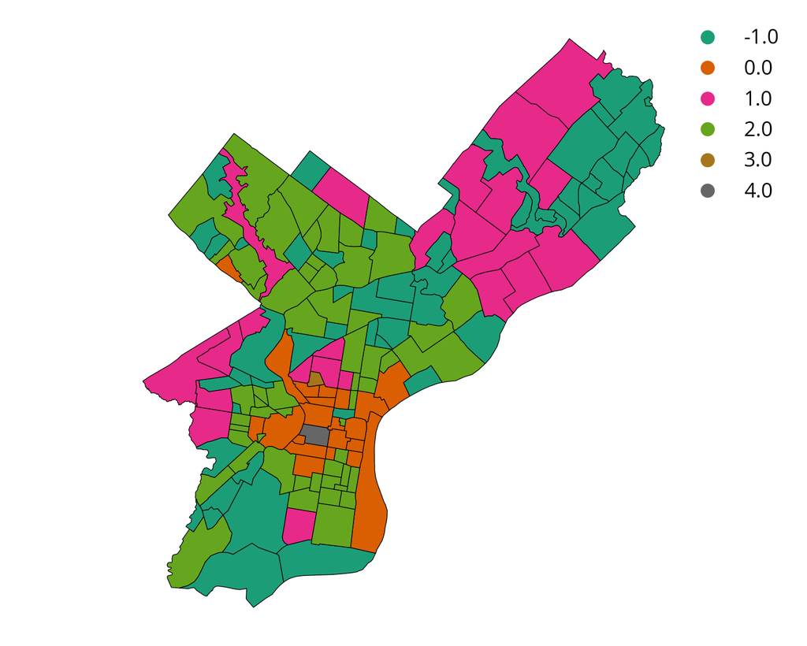

```python
# plot the data
airbnb2 = airbnb2.to_crs(epsg=3857)

# setup the figure
f, ax = plt.subplots(figsize=(10, 8))

# plot, coloring by label column
# specify categorical data and add legend
airbnb2.plot(
    column="label",
    cmap="Dark2",
    categorical=True,
    legend=True,
    edgecolor="k",
    lw=0.5,
    ax=ax,
)


ax.set_axis_off()
plt.axis("equal");
```

### Step 5: Plot an interactive map

Use altair to plot the clustering results with a tooltip for neighborhood name and tooltip.

**Hint:** See [week 3B's lecture](https://musa-550-fall-2022.github.io/slides/lecture-3B.html) on interactive choropleth's with altair

```python
# plot map, where variables ares nested within `properties`,
(
    alt.Chart(airbnb2.to_crs(epsg=4326))
    .mark_geoshape()
    .properties(
        width=500,
        height=400,
    )
    .encode(
        tooltip=["Name:N", "label:N"],
        color=alt.Color("label:N", scale=alt.Scale(scheme="Dark2")),
    )
)
```

[interactive chart not shown]

## Based on these results, where would you want to stay?

Group 2!

## More clustering on Wednesday!